# QSBS Practical 5 — Multiple regression: more than one predictor

# Introduction

Up to now every regression model had a single predictor. In this practical we add more predictors (Dormann, Chap. 15 and 16). In principle nothing changes: the model simply gets one more term, e.g. $y \sim \mathrm{NegBin}(\mu = e^{a + b x_1 + c x_2}, \theta)$, and `glm()` estimates all coefficients by maximum likelihood. In practice, four complications arise:

1. **Visualising** the data and the model, because a figure has only two axes. The usual solutions are *panel plots* (one panel per level of a second predictor), *all-in-one plots* with different symbols or colours per group, and for two continuous predictors *effect plots* or *image/contour plots* of the fitted surface.
2. **Interactions.** Two predictors interact when the effect of one depends on the value of the other. In a figure this shows up as lines with *different slopes*; in the model as a product term `x1:x2` (R’s `x1 * x2` means `x1 + x2 + x1:x2`). The coefficient of the interaction is the *change in slope* of one predictor per unit of the other. If an interaction is in the model, its main effects must stay in the model, even if they are not significant (the **marginality principle**, Nelder 1977).
3. **Collinearity.** Predictors that are strongly correlated with each other ($|r| > 0.7$, Dormann et al. 2013) cannot be separated by the model: their coefficients become unstable and their standard errors inflate (quantified by the *variance inflation factor*, VIF, which should stay below 10). The remedy is to check correlations *before* modelling and keep only one predictor of each correlated group.
4. **Model selection.** With several predictors and their interactions, many candidate models exist. The full model is compared with simpler models by likelihood-ratio tests (`anova()`) or by information criteria (AIC, BIC; BIC penalises complexity more strongly and prefers simpler models). Backward stepwise selection (`step()`) drops one term at a time; best-subset selection (`MuMIn::dredge()`) fits all sub-models and ranks them. Note that the `anova()` table of a single model is *sequential*: each term is tested after the terms above it, so the order of the terms matters when predictors are correlated.

**This practical is different from the previous ones: you do not have to write any R code** (occasionally you might use R to calculate coefficient-backtransforms). All output and figures are produced for you, and the code that produced them is shown so that you can see how it was done. Your task is to *read and interpret* the output, exactly as you would when reading a paper or a report. Write down your answers in a text document.

The data come from the `qsbsdata` package; in addition `MASS` (negative binomial GLM), `car` (variance inflation factors) and `MuMIn` (best-subset regression) are used.

```r
library(qsbsdata)
library(MASS)
library(car)
library(MuMIn)
```

# Commands used in this practical

For reference only — you do not need to run them.

```r
# Model formulae with several predictors
y ~ x1 + x2              # additive: two main effects
y ~ x1 * x2              # main effects plus interaction (= x1 + x2 + x1:x2)
y ~ x1 + x2 + x1:x2      # the same, written out
update(fm, . ~ . - x1:x2)  # drop a term from an existing model

# Sequential analysis-of-deviance table of ONE model (order of terms matters!)
anova(fm, test = "F")      # gaussian / quasi families
anova(fm, test = "Chisq")  # poisson / binomial
anova(fm_small, fm_big)    # compare two nested models

# Predicted value for a combination of predictors
predict(fm, newdata = data.frame(x1 = 3, f = "level"), type = "response")

# Collinearity
cor(d[, c("x1", "x2", "x3")])
pairs(d[, c("x1", "x2", "x3")])
vif(fm)                    # variance inflation factors (package car)

# Model selection
AIC(fm1, fm2, fm3); BIC(fm1, fm2, fm3)
step(fm)                   # backward stepwise by AIC
step(fm, k = log(n))       # backward stepwise by BIC
dredge(fm, rank = "AIC")   # all sub-models (package MuMIn; needs na.action = na.fail)

# Visualising two continuous predictors
z <- outer(x1seq, x2seq, function(a, b) predict(fm, newdata = data.frame(x1 = a, x2 = b)))
image(x1seq, x2seq, z); contour(x1seq, x2seq, z, add = TRUE)
```

# Exercise 1 — Two categorical predictors

Asghar et al. (2015, *Science*) measured the telomere length of great reed warbler chicks at 9 days of age (`OffBTL`, in `birdmalariaO`) and asked whether it depends on the malaria infection status of the mother (`mmal`: healthy or infected) and on the sex of the chick. Both predictors are factors with two levels, so there are four groups.

```r
bird <- birdmalariaO
bird$Sex  <- factor(bird$Sex,  levels = c(0, 1), labels = c("male", "female"))
bird$mmal <- factor(bird$mmal, levels = c(0, 1), labels = c("healthy", "infected"))
bird <- bird[complete.cases(bird[, c("OffBTL", "Sex", "mmal")]), ]

table(bird$Sex, bird$mmal)
```

```
##
##          healthy infected
##   male        57       45
##   female      40       37
```

```r
round(tapply(bird$OffBTL, list(bird$Sex, bird$mmal), mean), 3)
```

```
##        healthy infected
## male     0.973    0.806
## female   1.009    0.823
```

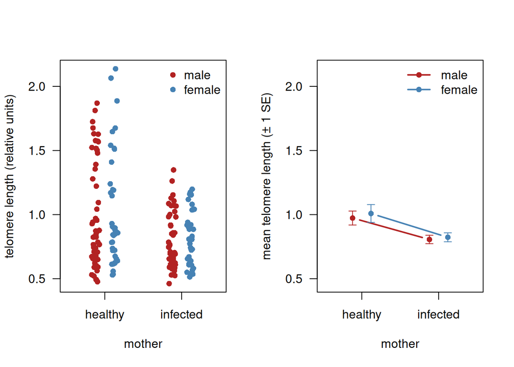

Telomere length of great reed warbler chicks by mother’s malaria status and chick sex (red = male, blue = female). Left: all data; right: group means ± 1 standard error, connected per sex (an *interaction plot*). Male and female points are shifted slightly sideways so that they do not overlap.

```r
cols <- c(male = "firebrick", female = "steelblue")
off  <- c(male = -0.12, female = 0.12)                 # horizontal shift per sex
yl   <- range(bird$OffBTL)

par(mfrow = c(1, 2))
# left: all observations, jittered around the shifted group positions
xpos <- as.numeric(bird$mmal) + off[as.character(bird$Sex)] + runif(nrow(bird), -0.05, 0.05)
plot(xpos, bird$OffBTL, pch = 16, col = cols[as.character(bird$Sex)], las = 1,
     xlim = c(0.5, 2.5), ylim = yl, xaxt = "n",
     xlab = "mother", ylab = "telomere length (relative units)")
axis(1, at = 1:2, labels = levels(bird$mmal))
legend("topright", bty = "n", pch = 16, col = cols, legend = names(cols))

# right: group means ± 1 SE, same y-axis, same horizontal shift
m  <- tapply(bird$OffBTL, list(bird$mmal, bird$Sex), mean)
se <- tapply(bird$OffBTL, list(bird$mmal, bird$Sex), function(x) sd(x) / sqrt(length(x)))
plot(NA, xlim = c(0.5, 2.5), ylim = yl, xaxt = "n", las = 1,
     xlab = "mother", ylab = "mean telomere length (± 1 SE)")
axis(1, at = 1:2, labels = levels(bird$mmal))
for (sx in c("male", "female")) {
  x <- 1:2 + off[sx]
  lines(x, m[, sx], type = "b", pch = 16, lwd = 2, col = cols[sx])
  arrows(x, m[, sx] - se[, sx], x, m[, sx] + se[, sx], angle = 90, code = 3, length = 0.05, col = cols[sx])
}
legend("topright", bty = "n", pch = 16, lwd = 2, col = cols, legend = names(cols))
```

```r
par(mfrow = c(1, 1))
```

Two gaussian GLMs were fitted: an **additive** model and a model **with interaction**.

```r
fb_add <- glm(OffBTL ~ Sex + mmal, family = gaussian, data = bird)
fb_int <- glm(OffBTL ~ Sex * mmal, family = gaussian, data = bird)

summary(fb_int)$coefficients
```

```
##                           Estimate Std. Error   t value     Pr(>|t|)
## (Intercept)             0.97325432 0.04555958 21.362232 1.235502e-50
## Sexfemale               0.03540190 0.07094725  0.498989 6.184138e-01
## mmalinfected           -0.16706938 0.06859201 -2.435697 1.586587e-02
## Sexfemale:mmalinfected -0.01846687 0.10421307 -0.177203 8.595539e-01
```

```r
anova(fb_int, test = "F")
```

```
## Analysis of Deviance Table
##
## Model: gaussian, link: identity
##
## Response: OffBTL
##
## Terms added sequentially (first to last)
##
##
##          Df Deviance Resid. Df Resid. Dev       F    Pr(>F)
## NULL                       178     22.086
## Sex       1  0.01747       177     22.068  0.1477 0.7012309
## mmal      1  1.35984       176     20.709 11.4936 0.0008631 ***
## Sex:mmal  1  0.00372       175     20.705  0.0314 0.8595539
## ---
## Signif. codes:  0 '***' 0.001 '**' 0.01 '*' 0.05 '.' 0.1 ' ' 1
```

```r
summary(fb_add)$coefficients
```

```
##                 Estimate Std. Error    t value     Pr(>|t|)
## (Intercept)   0.97678378 0.04086226 23.9043027 3.696272e-57
## Sexfemale     0.02684296 0.05182413  0.5179626 6.051348e-01
## mmalinfected -0.17506949 0.05149732 -3.3995842 8.349140e-04
```

```r
AIC(fb_add, fb_int)
```

```
##        df      AIC
## fb_add  4 129.9060
## fb_int  5 131.8739
```

1. Which of the four groups is the *reference group* that the intercept of the interaction model refers to, and why that one? Reconstruct from the four coefficients of `fb_int` the fitted mean telomere length of (i) a male chick of a healthy mother, (ii) a female chick of a healthy mother, (iii) a male chick of an infected mother and (iv) a female chick of an infected mother. Compare your four numbers with the table of group means.
2. What does the coefficient `Sexfemale:mmalinfected` measure, in words? Judging from its estimate, its p-value and the interaction plot: do sex and mother’s infection status interact?
3. The `anova()` table tests the terms *sequentially*. Explain what the three rows test. Which term explains most of the deviance? What fraction of the total deviance (the `NULL` row) is explained by the full interaction model?
4. Which of the two models would you report, and why? Support your choice with the AIC values *and* with the F-test of the interaction. Then give the interpretation of the `mmalinfected` coefficient of the model you chose, including its uncertainty (estimate ± SE), in one sentence a biologist would understand.
5. In the additive model the `Sexfemale` coefficient is not significant. Is it allowed to remove `Sex` from the additive model? Is it allowed to remove `Sex` from the interaction model? Explain the difference.

# Exercise 2 — A continuous and a categorical predictor (ANCOVA)

`regrowth` contains the fruit production (`Fruit`, mg) of 40 plants, their initial root diameter (`Root`, mm, measured *before* the treatment) and whether the plant was grazed by rabbits (`Grazing`: Grazed / Ungrazed).

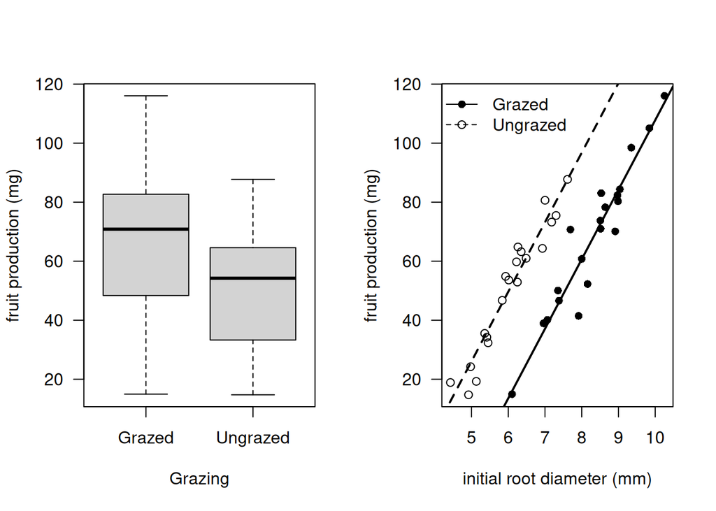

Fruit production of grazed and ungrazed plants. Left: ignoring root size. Right: as a function of root size, with the fitted lines of the additive model `Fruit ~ Root + Grazing`.

```r
fg_add <- glm(Fruit ~ Root + Grazing, family = gaussian, data = regrowth)

par(mfrow = c(1, 2))
boxplot(Fruit ~ Grazing, data = regrowth, las = 1, ylab = "fruit production (mg)")
plot(Fruit ~ Root, data = regrowth, pch = c(16, 1)[regrowth$Grazing], las = 1,
     xlab = "initial root diameter (mm)", ylab = "fruit production (mg)")
cf <- coef(fg_add)
abline(a = cf["(Intercept)"], b = cf["Root"], lwd = 2)
abline(a = cf["(Intercept)"] + cf["GrazingUngrazed"], b = cf["Root"], lwd = 2, lty = 2)
legend("topleft", bty = "n", pch = c(16, 1), lty = c(1, 2), legend = c("Grazed", "Ungrazed"))
```

```r
par(mfrow = c(1, 1))

tapply(regrowth$Fruit, regrowth$Grazing, mean)
```

```
##   Grazed Ungrazed
##  67.9405  50.8805
```

```r
tapply(regrowth$Root, regrowth$Grazing, mean)
```

```
##   Grazed Ungrazed
##   8.3094   6.0529
```

```r
summary(fg_add)$coefficients
```

```
##                   Estimate Std. Error   t value     Pr(>|t|)
## (Intercept)     -127.82936   9.664095 -13.22725 1.349804e-15
## Root              23.56005   1.148771  20.50892 8.408231e-22
## GrazingUngrazed   36.10325   3.357396  10.75335 6.107286e-13
```

```r
# the same additive model, terms entered in two different orders
anova(glm(Fruit ~ Grazing + Root, family = gaussian, data = regrowth), test = "F")
```

```
## Analysis of Deviance Table
##
## Model: gaussian, link: identity
##
## Response: Fruit
##
## Terms added sequentially (first to last)
##
##
##         Df Deviance Resid. Df Resid. Dev       F    Pr(>F)
## NULL                       39    23743.8
## Grazing  1   2910.4        38    20833.4  63.929 1.397e-09 ***
## Root     1  19148.9        37     1684.5 420.616 < 2.2e-16 ***
## ---
## Signif. codes:  0 '***' 0.001 '**' 0.01 '*' 0.05 '.' 0.1 ' ' 1
```

```r
anova(glm(Fruit ~ Root + Grazing, family = gaussian, data = regrowth), test = "F")
```

```
## Analysis of Deviance Table
##
## Model: gaussian, link: identity
##
## Response: Fruit
##
## Terms added sequentially (first to last)
##
##
##         Df Deviance Resid. Df Resid. Dev      F    Pr(>F)
## NULL                       39    23743.8
## Root     1  16795.0        38     6948.8 368.91 < 2.2e-16 ***
## Grazing  1   5264.4        37     1684.5 115.63 6.107e-13 ***
## ---
## Signif. codes:  0 '***' 0.001 '**' 0.01 '*' 0.05 '.' 0.1 ' ' 1
```

```r
# the model with interaction
fg_int <- glm(Fruit ~ Root * Grazing, family = gaussian, data = regrowth)
summary(fg_int)$coefficients
```

```
##                          Estimate Std. Error    t value     Pr(>|t|)
## (Intercept)          -125.1730569  12.811165 -9.7706222 1.150540e-11
## Root                   23.2403732   1.530771 15.1821314 3.173208e-17
## GrazingUngrazed        30.8057049  16.841823  1.8291194 7.567489e-02
## Root:GrazingUngrazed    0.7560338   2.354111  0.3211547 7.499503e-01
```

```r
anova(fg_add, fg_int, test = "F")
```

```
## Analysis of Deviance Table
##
## Model 1: Fruit ~ Root + Grazing
## Model 2: Fruit ~ Root * Grazing
##   Resid. Df Resid. Dev Df Deviance      F Pr(>F)
## 1        37     1684.5
## 2        36     1679.7  1   4.8122 0.1031   0.75
```

1. According to the boxplot, grazed plants produce *more* fruit than ungrazed plants (means 68 vs 51 mg). According to the coefficient `GrazingUngrazed` of the additive model, ungrazed plants produce *more* fruit. Both statements are based on the same data. Explain, using the right-hand figure and the mean root diameters per group, how this apparent contradiction arises and which of the two statements answers the question “does grazing reduce fruit production?”.
2. Write down the two fitted regression lines (one per grazing group) in the form $\hat{y} = a + b \cdot \mathrm{Root}$ from the coefficients of `fg_add`. What does the model assume about the two lines?
3. The two `anova()` tables are for the *same* model, but the deviance attributed to `Grazing` is 2910 in one and 5264 in the other. Explain why the order of the terms matters here (hint: are `Root` and `Grazing` independent in this data set?). Why does the *residual* deviance not depend on the order?
4. In the interaction model, what does the coefficient `Root:GrazingUngrazed` represent? Is there evidence that the effect of root size differs between grazed and ungrazed plants? Which model would you report?
5. Root diameter was measured before the grazing treatment. Why is that important for the interpretation in (a)? What would change in your interpretation if root diameter had been measured *after* grazing?

# Exercise 3 — Interaction between a continuous and a categorical predictor

We return to the `wells` data (Practicals 3 and 4b): the number of contaminated wells `y` out of `n` in 20 areas, with the nitrate concentration (`nitrate`, mg/l) and whether the area is sewered (`sewer`: yes/no). Because the data were overdispersed, a **quasi-binomial** model is used.

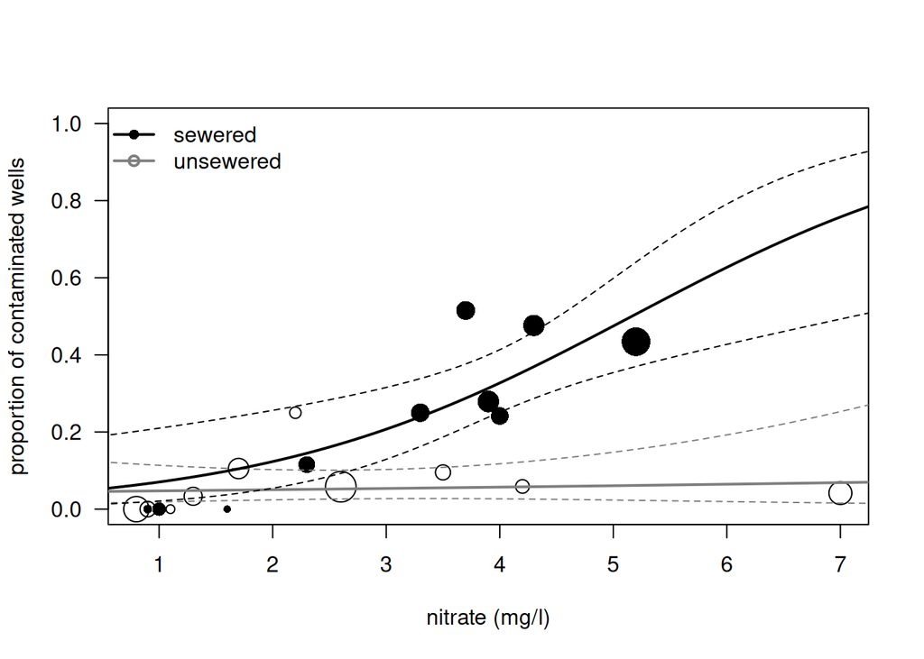

Proportion of contaminated wells against nitrate concentration in sewered (filled) and unsewered (open) areas. Symbol size is proportional to the number of wells. Lines: fitted curves of the interaction model with 95 % confidence bands.

```r
fw_int <- glm(cbind(y, n - y) ~ nitrate * sewer, family = quasibinomial, data = wells)
fw_add <- glm(cbind(y, n - y) ~ nitrate + sewer, family = quasibinomial, data = wells)

plot(y / n ~ nitrate, data = wells, cex = sqrt(n) / 3, pch = c(1, 16)[factor(sewer)], las = 1,
     xlab = "nitrate (mg/l)", ylab = "proportion of contaminated wells", ylim = c(0, 1))
xnew <- seq(0, 8, length = 100)
for (s in c("no", "yes")) {
  pr <- predict(fw_int, newdata = data.frame(nitrate = xnew, sewer = s), se.fit = TRUE)
  matlines(xnew, plogis(cbind(pr$fit, pr$fit - 2 * pr$se.fit, pr$fit + 2 * pr$se.fit)),
           lty = c(1, 2, 2), col = ifelse(s == "yes", "black", "grey50"), lwd = c(2, 1, 1))
}
legend("topleft", bty = "n", pch = c(16, 1), col = c("black", "grey50"), lwd = 2,
       legend = c("sewered", "unsewered"))
```

```r
summary(fw_int)$coefficients
```

```
##                     Estimate Std. Error    t value     Pr(>|t|)
## (Intercept)      -3.06888250  0.5983799 -5.1286522 0.0001010547
## nitrate           0.06607054  0.1656261  0.3989139 0.6952302636
## seweryes         -0.13285511  1.0104045 -0.1314871 0.8970292106
## nitrate:seweryes  0.55407961  0.2539352  2.1819726 0.0443687501
```

```r
summary(fw_int)$dispersion
```

```
## [1] 2.109884
```

```r
anova(fw_int, test = "F")
```

```
## Analysis of Deviance Table
##
## Model: quasibinomial, link: logit
##
## Response: cbind(y, n - y)
##
## Terms added sequentially (first to last)
##
##
##               Df Deviance Resid. Df Resid. Dev       F    Pr(>F)
## NULL                             19    146.956
## nitrate        1   34.796        18    112.160 16.4918 0.0009079 ***
## sewer          1   66.778        17     45.382 31.6502 3.792e-05 ***
## nitrate:sewer  1   11.295        16     34.087  5.3532 0.0343083 *
## ---
## Signif. codes:  0 '***' 0.001 '**' 0.01 '*' 0.05 '.' 0.1 ' ' 1
```

```r
anova(fw_add, fw_int, test = "F")
```

```
## Analysis of Deviance Table
##
## Model 1: cbind(y, n - y) ~ nitrate + sewer
## Model 2: cbind(y, n - y) ~ nitrate * sewer
##   Resid. Df Resid. Dev Df Deviance      F  Pr(>F)
## 1        17     45.382
## 2        16     34.087  1   11.295 5.3532 0.03431 *
## ---
## Signif. codes:  0 '***' 0.001 '**' 0.01 '*' 0.05 '.' 0.1 ' ' 1
```

1. Write down the fitted model on the logit scale for unsewered areas and for sewered areas, each in the form $\mathrm{logit}(p) = a + b \cdot \mathrm{nitrate}$, using the four coefficients.
2. Calculate by hand (calculator) the fitted probability of contamination at a nitrate concentration of 4 mg/l in an unsewered and in a sewered area. Recall that $p = e^{\eta} / (1 + e^{\eta})$.
3. The `nitrate` main effect has $p = 0.70$ and the `seweryes` main effect has $p = 0.90$, yet the interaction is significant. Explain what the two non-significant main effects mean in this model (what exactly do they test?) and why they must nevertheless stay in the model.
4. Describe the interaction in words for a report on groundwater quality: what is the effect of nitrate in unsewered areas, what is it in sewered areas, and what does this suggest about the *source* of the contamination? Use the figure.
5. The `anova()` comparison of the additive and the interaction model gives $F = 5.35$, $p = 0.034$. Why is an F-test used here rather than a $\chi^2$ test? What would have happened to this p-value if the ordinary binomial family had been used (think back to Practical 4b, Exercise 2)?

# Exercise 4 — Interaction and model simplification with a negative binomial GLM

In Practical 4b we found that macro-fauna richness (`RIKZdat`) depends on tidal height `NAP` and that the residuals also showed an effect of beach `exposure` (three levels: 8, 10, 11). Four negative binomial models were fitted:

```r
RIKZdat$exposure <- factor(RIKZdat$exposure)

fr_nap <- glm.nb(Richness ~ NAP, data = RIKZdat)
fr_exp <- glm.nb(Richness ~ exposure, data = RIKZdat)
fr_add <- glm.nb(Richness ~ NAP + exposure, data = RIKZdat)
fr_int <- glm.nb(Richness ~ NAP * exposure, data = RIKZdat)

summary(fr_int)$coefficients
```

```
##                  Estimate Std. Error    z value     Pr(>|z|)
## (Intercept)     2.5485423  0.1684491 15.1294499 1.035574e-51
## NAP            -0.3239406  0.1776522 -1.8234538 6.823469e-02
## exposure10     -0.6323736  0.1987119 -3.1823645 1.460778e-03
## exposure11     -1.3537393  0.2198968 -6.1562468 7.448912e-10
## NAP:exposure10 -0.3383220  0.2142170 -1.5793423 1.142576e-01
## NAP:exposure11 -0.2435137  0.2437588 -0.9989945 3.177974e-01
```

```r
anova(fr_add, fr_int)
```

```
## Likelihood ratio tests of Negative Binomial Models
##
## Response: Richness
##            Model    theta Resid. df    2 x log-lik.   Test    df LR stat.   Pr(Chi)
## 1 NAP + exposure 15.25376        41       -196.0406
## 2 NAP * exposure 18.25390        39       -193.7610 1 vs 2     2 2.279608 0.3198817
```

```r
AIC(fr_nap, fr_exp, fr_add, fr_int)
```

```
##        df      AIC
## fr_nap  3 231.7456
## fr_exp  4 239.2391
## fr_add  5 206.0406
## fr_int  7 207.7610
```

```r
summary(fr_add)$coefficients
```

```
##               Estimate Std. Error   z value     Pr(>|z|)
## (Intercept)  2.5831487 0.17500217 14.760667 2.626718e-49
## NAP         -0.5690938 0.08565631 -6.643921 3.054464e-11
## exposure10  -0.6577734 0.20502891 -3.208198 1.335693e-03
## exposure11  -1.3882048 0.22636325 -6.132642 8.643143e-10
```

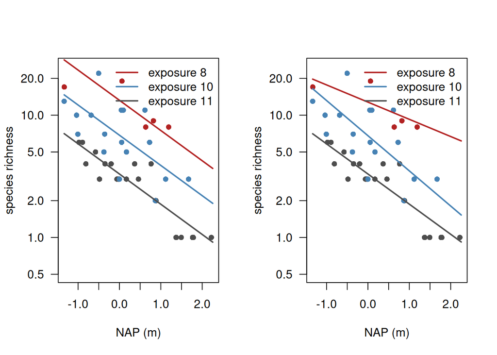

Species richness against NAP for the three exposure classes. Left: additive model (parallel lines on the log scale). Right: interaction model (separate slopes).

```r
cols <- c("8" = "firebrick", "10" = "steelblue", "11" = "grey30")
nap_new <- seq(min(RIKZdat$NAP), max(RIKZdat$NAP), length = 100)
par(mfrow = c(1, 2))
for (m in list(fr_add, fr_int)) {
  plot(Richness ~ NAP, data = RIKZdat, pch = 16, col = cols[as.character(exposure)], las = 1,
       xlab = "NAP (m)", ylab = "species richness", log = "y", ylim = c(0.5, 25))
  for (e in levels(RIKZdat$exposure)) {
    lines(nap_new, predict(m, newdata = data.frame(NAP = nap_new, exposure = e), type = "response"),
          col = cols[e], lwd = 2)
  }
  legend("topright", bty = "n", col = cols, lwd = 2, legend = paste("exposure", names(cols)))
}
```

```r
par(mfrow = c(1, 1))
```

1. In the interaction model, which combination of NAP and exposure does the intercept refer to? Write down the slope of `NAP` (on the log scale) for each of the three exposure classes as a sum of coefficients.
2. Is the interaction needed? Answer using the likelihood-ratio test in `anova(fr_add, fr_int)` and the AIC table. Why does the test have 2 degrees of freedom?
3. The AIC table contains four models. Rank them and state the AIC difference between the best and each of the others. Which of the two single-predictor models is better, and how does that compare with the conclusion from Practical 4b where only `NAP` was used?
4. Use the coefficients of the additive model to describe the effect of exposure: by which *factor* does the expected richness differ between exposure 8 and exposure 11 at a given NAP? And by which factor does richness change per metre of NAP? (You need `exp()`; a calculator will do.)
5. Why is the y-axis of the figure drawn on a log scale, and what property of the additive model becomes visible in that representation that would be hidden on a linear axis?

# Exercise 5 — Collinearity

For the Galápagos islands (`gala`) several possible predictors of plant species richness are available: island area, elevation, distance to the nearest island and area of the adjacent island. All four are strongly right-skewed and have been log-transformed. Before fitting a multiple regression, we check how the predictors are related to each other.

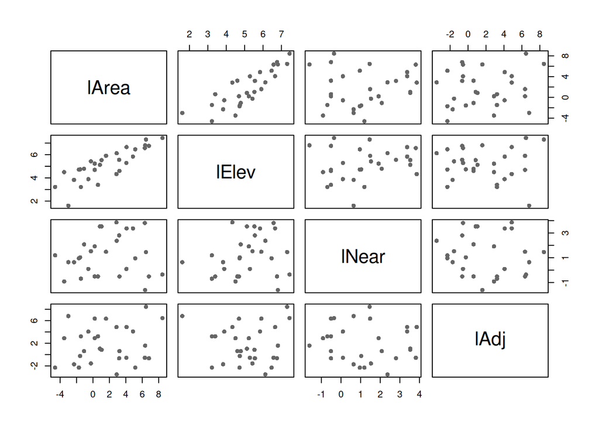

Pairwise scatter plots of the four log-transformed predictors for the Galápagos data.

```r
g <- gala
g$lArea <- log(g$Area); g$lElev <- log(g$Elevation)
g$lNear <- log(g$Nearest.dist); g$lAdj <- log(g$Adjacent.isl.area)

pairs(g[, c("lArea", "lElev", "lNear", "lAdj")], pch = 16, col = "grey40")
```

```r
round(cor(g[, c("lArea", "lElev", "lNear", "lAdj")]), 2)
```

```
##       lArea lElev lNear  lAdj
## lArea  1.00  0.83  0.10  0.15
## lElev  0.83  1.00  0.20 -0.01
## lNear  0.10  0.20  1.00 -0.09
## lAdj   0.15 -0.01 -0.09  1.00
```

```r
m_area <- glm.nb(Species ~ lArea, data = g)
m_elev <- glm.nb(Species ~ lElev, data = g)
m_both <- glm.nb(Species ~ lArea + lElev, data = g)
m_all  <- glm.nb(Species ~ lArea + lElev + lNear + lAdj, data = g)

round(summary(m_area)$coefficients, 3)
```

```
##             Estimate Std. Error z value Pr(>|z|)
## (Intercept)    3.150      0.140  22.440        0
## lArea          0.367      0.036  10.204        0
```

```r
round(summary(m_elev)$coefficients, 3)
```

```
##             Estimate Std. Error z value Pr(>|z|)
## (Intercept)    0.051      0.683   0.075     0.94
## lElev          0.761      0.127   5.986     0.00
```

```r
round(summary(m_both)$coefficients, 3)
```

```
##             Estimate Std. Error z value Pr(>|z|)
## (Intercept)    3.449      0.773   4.461    0.000
## lArea          0.389      0.065   5.962    0.000
## lElev         -0.065      0.165  -0.396    0.692
```

```r
round(summary(m_all)$coefficients, 3)
```

```
##             Estimate Std. Error z value Pr(>|z|)
## (Intercept)    3.326      0.769   4.326    0.000
## lArea          0.375      0.064   5.854    0.000
## lElev          0.001      0.164   0.005    0.996
## lNear         -0.130      0.072  -1.801    0.072
## lAdj          -0.030      0.036  -0.827    0.408
```

```r
vif(m_all)
```

```
##    lArea    lElev    lNear     lAdj
## 3.571490 3.585532 1.053126 1.066036
```

```r
AIC(m_area, m_elev, m_both, m_all)
```

```
##        df      AIC
## m_area  3 273.9926
## m_elev  3 294.3806
## m_both  4 275.8631
## m_all   6 276.6726
```

1. Which pair of predictors is collinear according to Dormann’s rule of thumb? Give a physical reason why these two variables are so strongly correlated on the Galápagos.
2. On its own, `lElev` is a highly significant predictor ($z = 6.0$). In the model with both `lArea` and `lElev`, its coefficient is $-0.07$ with $p = 0.69$. Explain what happened. Does this mean that elevation has no effect on species richness?
3. Compare the standard error of `lArea` in `m_area` with that in `m_both`. By what factor did it increase? Relate this to the variance inflation factors: what does a VIF of 3.6 mean, and would Dormann consider it a problem?
4. Which of the four models would you choose as the final model, and on what grounds (AIC, parsimony, interpretability)? Formulate a sentence for the discussion section of a paper that honestly states what the data can and cannot tell us about the roles of area and elevation.
5. Suppose a colleague argues: “Elevation is biologically the more relevant variable, because higher islands have more habitat types, so we should keep elevation and drop area.” Can the data decide this argument? What kind of data *could*?

# Exercise 6 — Two continuous predictors and their interaction

`loyn` contains the abundance of forest birds (`ABUND`, birds per 20-minute census) in 56 forest fragments in Victoria, Australia, together with the fragment area (`AREA`, ha, log10-transformed below), the grazing intensity (`GRAZE`, index 1 = light to 5 = heavy) and several other variables. Here we look at area and grazing together, treating grazing as a continuous predictor.

```r
loyn$lAREA <- log10(loyn$AREA)

fl_add <- lm(ABUND ~ lAREA + GRAZE, data = loyn)
fl_int <- lm(ABUND ~ lAREA * GRAZE, data = loyn)

round(summary(fl_add)$coefficients, 3)
```

```
##             Estimate Std. Error t value Pr(>|t|)
## (Intercept)   21.603      3.092   6.987        0
## lAREA          6.890      1.290   5.341        0
## GRAZE         -2.854      0.713  -4.005        0
```

```r
round(summary(fl_int)$coefficients, 3)
```

```
##             Estimate Std. Error t value Pr(>|t|)
## (Intercept)   26.558      3.358   7.910    0.000
## lAREA          2.112      2.038   1.037    0.305
## GRAZE         -4.547      0.885  -5.138    0.000
## lAREA:GRAZE    2.142      0.736   2.911    0.005
```

```r
anova(fl_add, fl_int)
```

```
## Analysis of Variance Table
##
## Model 1: ABUND ~ lAREA + GRAZE
## Model 2: ABUND ~ lAREA * GRAZE
##   Res.Df    RSS Df Sum of Sq      F   Pr(>F)
## 1     53 2200.9
## 2     52 1892.5  1    308.49 8.4766 0.005287 **
## ---
## Signif. codes:  0 '***' 0.001 '**' 0.01 '*' 0.05 '.' 0.1 ' ' 1
```

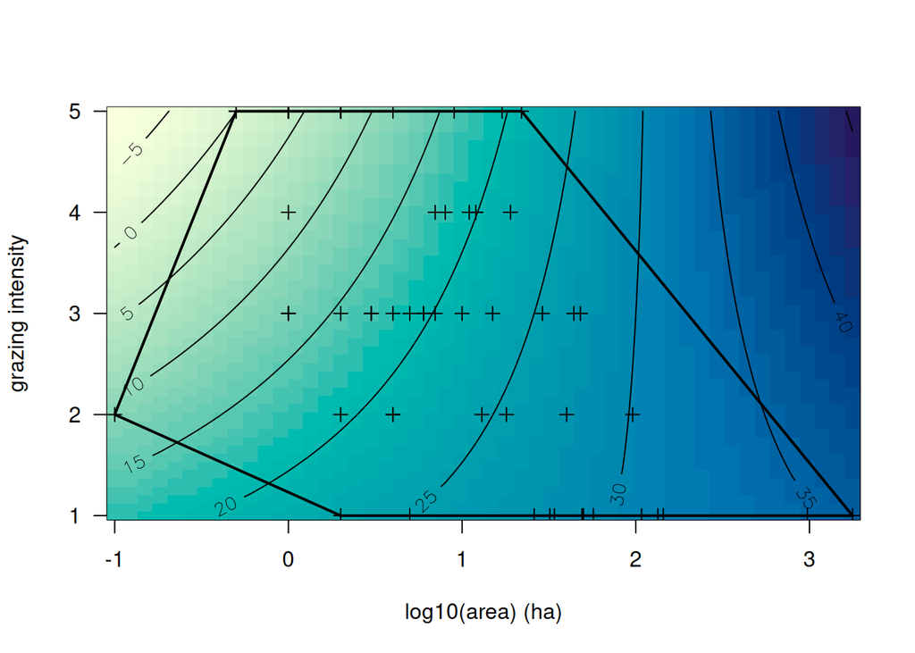

Fitted bird abundance as a function of log10(area) and grazing intensity for the interaction model, shown as a colour image with contour lines. The crosses are the observed combinations of the two predictors; the polygon is their convex hull.

```r
area_seq  <- seq(min(loyn$lAREA), max(loyn$lAREA), length = 50)
graze_seq <- seq(1, 5, length = 50)
z <- outer(area_seq, graze_seq,
           function(a, gr) predict(fl_int, newdata = data.frame(lAREA = a, GRAZE = gr)))

image(area_seq, graze_seq, z, col = hcl.colors(50, "YlGnBu", rev = TRUE), las = 1,
      xlab = "log10(area) (ha)", ylab = "grazing intensity")
contour(area_seq, graze_seq, z, add = TRUE, labcex = 0.9)
points(loyn$lAREA, loyn$GRAZE, pch = 3)
ch <- chull(cbind(loyn$lAREA, loyn$GRAZE))
polygon(cbind(loyn$lAREA, loyn$GRAZE)[ch, ], lwd = 2)
```

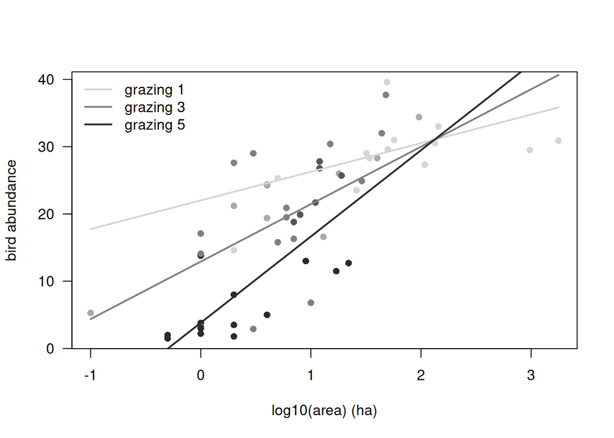

The same interaction model as lines: fitted abundance against log10(area) for grazing intensity 1, 3 and 5. Points are coloured by grazing class (light = light grazing).

```r
plot(ABUND ~ lAREA, data = loyn, pch = 16, col = grey(1 - loyn$GRAZE / 6), las = 1,
     xlab = "log10(area) (ha)", ylab = "bird abundance")
for (gr in c(1, 3, 5)) {
  lines(area_seq, predict(fl_int, newdata = data.frame(lAREA = area_seq, GRAZE = gr)),
        lwd = 2, col = grey(1 - gr / 6))
}
legend("topleft", bty = "n", lwd = 2, col = grey(1 - c(1, 3, 5) / 6),
       legend = c("grazing 1", "grazing 3", "grazing 5"))
```

1. In the additive model, what is the interpretation of the `lAREA` coefficient (6.89) and of the `GRAZE` coefficient ($-2.85$)? Pay attention to the units: what does “one unit of `lAREA`” mean for the actual area?
2. In the interaction model the `lAREA` main effect is 2.11 with $p = 0.30$. Does this mean that area has no effect on bird abundance? What exactly does this coefficient represent in the presence of the interaction (hint: at what grazing intensity is it the slope — and does that value occur in the data)?
3. Use the coefficients to calculate the slope of abundance against `lAREA` at grazing intensity 1 and at grazing intensity 5. Describe the interaction in words: is it synergistic or antagonistic (Dormann, Sect. 15.2)?
4. Look at the image/contour plot. Where in the predictor space are the fitted values highest, and where lowest? Which corner(s) of the plot contain no data, and why should you refrain from interpreting the model there?
5. Dormann (Sect. 15.2, footnote 4) warns that a significant interaction can be an artefact of an unmodelled *non-linear* effect of one of the predictors. Suggest how you would check this for the present model (which alternative model would you compare it with?).

# Exercise 7 — Model selection

We now use all predictors in `loyn` to explain bird abundance: `lAREA`, `lDIST` (log10 distance to the nearest fragment), `lLDIST` (log10 distance to the nearest *larger* fragment), `YR.ISOL` (year of isolation), `GRAZE` and `ALT` (altitude). A model with only main effects was fitted and simplified in three ways: backward stepwise selection by AIC, backward stepwise selection by BIC, and best-subset selection (all 64 sub-models) ranked by AIC.

```r
loyn$lDIST  <- log10(loyn$DIST)
loyn$lLDIST <- log10(loyn$LDIST)

round(cor(loyn[, c("lAREA", "lDIST", "lLDIST", "YR.ISOL", "GRAZE", "ALT")]), 2)
```

```
##         lAREA lDIST lLDIST YR.ISOL GRAZE   ALT
## lAREA    1.00  0.30   0.38    0.28 -0.56  0.28
## lDIST    0.30  1.00   0.60   -0.02 -0.14 -0.22
## lLDIST   0.38  0.60   1.00   -0.16 -0.03 -0.27
## YR.ISOL  0.28 -0.02  -0.16    1.00 -0.64  0.23
## GRAZE   -0.56 -0.14  -0.03   -0.64  1.00 -0.41
## ALT      0.28 -0.22  -0.27    0.23 -0.41  1.00
```

```r
fl_full <- lm(ABUND ~ lAREA + lDIST + lLDIST + YR.ISOL + GRAZE + ALT, data = loyn,
              na.action = na.fail)
round(summary(fl_full)$coefficients, 3)
```

```
##             Estimate Std. Error t value Pr(>|t|)
## (Intercept) -125.697     91.692  -1.371    0.177
## lAREA          7.470      1.465   5.099    0.000
## lDIST         -0.907      2.676  -0.339    0.736
## lLDIST        -0.648      2.123  -0.305    0.761
## YR.ISOL        0.074      0.045   1.634    0.109
## GRAZE         -1.668      0.930  -1.793    0.079
## ALT            0.020      0.024   0.814    0.419
```

```r
round(vif(fl_full), 2)
```

```
##   lAREA   lDIST  lLDIST YR.ISOL   GRAZE     ALT
##    1.91    1.65    2.01    1.80    2.52    1.47
```

```r
fl_stepAIC <- step(fl_full, trace = 0)
fl_stepBIC <- step(fl_full, k = log(nrow(loyn)), trace = 0)

formula(fl_stepAIC)
```

```
## ABUND ~ lAREA + YR.ISOL + GRAZE
```

```r
formula(fl_stepBIC)
```

```
## ABUND ~ lAREA + GRAZE
```

```r
# one step of the BIC selection, shown in full
step(fl_full, k = log(nrow(loyn)), steps = 1)
```

```
## Start:  AIC=228.32
## ABUND ~ lAREA + lDIST + lLDIST + YR.ISOL + GRAZE + ALT
##
##           Df Sum of Sq    RSS    AIC
## - lLDIST   1      3.80 2000.7 224.40
## - lDIST    1      4.68 2001.5 224.43
## - ALT      1     27.02 2023.9 225.05
## - YR.ISOL  1    108.83 2105.7 227.27
## - GRAZE    1    131.07 2127.9 227.85
## <none>                 1996.8 228.32
## - lAREA    1   1059.75 3056.6 248.14
##
## Step:  AIC=224.4
## ABUND ~ lAREA + lDIST + YR.ISOL + GRAZE + ALT
```

```
##
## Call:
## lm(formula = ABUND ~ lAREA + lDIST + YR.ISOL + GRAZE + ALT, data = loyn,
##     na.action = na.fail)
##
## Coefficients:
## (Intercept)        lAREA        lDIST      YR.ISOL        GRAZE          ALT
##  -131.84739      7.29529     -1.30325      0.07658     -1.67573      0.02145
```

```r
dm <- dredge(fl_full, rank = "AIC")
```

```
## Fixed term is "(Intercept)"
```

```r
print(subset(dm, delta < 2), abbrev.names = FALSE)
```

```
## Global model call: lm(formula = ABUND ~ lAREA + lDIST + lLDIST + YR.ISOL + GRAZE +
##     ALT, data = loyn, na.action = na.fail)
## ---
## Model selection table
##    (Intercept)     ALT  GRAZE lAREA  lDIST lLDIST YR.ISOL df   logLik   AIC delta weight
## 39     -134.30         -1.902 7.166               0.07835  5 -180.555 371.1  0.00  0.228
## 40     -141.90 0.02586 -1.601 7.076               0.07991  6 -179.761 371.5  0.41  0.185
## 55     -113.40         -1.842 7.751        -1.646 0.06941  6 -180.036 372.1  0.96  0.141
## 47     -120.50         -1.939 7.487 -2.048        0.07354  6 -180.072 372.1  1.04  0.136
## 7        21.60         -2.854 6.890                        4 -182.257 372.5  1.40  0.113
## 23       25.74         -2.630 7.709        -2.190          5 -181.347 372.7  1.59  0.103
## 38     -236.70 0.03623        8.150               0.12480  5 -181.428 372.9  1.75  0.095
## Models ranked by AIC(x)
```

```r
AIC(fl_full, fl_stepAIC, fl_stepBIC)
```

```
##            df      AIC
## fl_full     8 375.0638
## fl_stepAIC  5 371.1092
## fl_stepBIC  4 372.5134
```

```r
BIC(fl_full, fl_stepAIC, fl_stepBIC)
```

```
##            df      BIC
## fl_full     8 391.2666
## fl_stepAIC  5 381.2360
## fl_stepBIC  4 380.6148
```

```r
round(summary(fl_stepAIC)$coefficients, 3)
```

```
##             Estimate Std. Error t value Pr(>|t|)
## (Intercept) -134.261     86.391  -1.554    0.126
## lAREA          7.166      1.273   5.631    0.000
## YR.ISOL        0.078      0.043   1.805    0.077
## GRAZE         -1.902      0.874  -2.175    0.034
```

1. Look at the correlation matrix and the VIFs of the full model. Is collinearity a problem here? Which pair of predictors is most strongly correlated, and is it a problem that they are both in the model?
2. In the full model only `lAREA` is significant, yet the model explains 68 % of the variance. Explain why a model can be highly significant as a whole while most of its individual coefficients are not (think of what a coefficient’s p-value tests when other, correlated predictors are in the model).
3. Read the displayed first step of the BIC selection. Explain the meaning of the rows: what does `<none>` represent, what does the row `- lLDIST` represent, and why is `- lAREA` at the bottom? Which term is removed in this step, and why?
4. Stepwise AIC ends with `lAREA + YR.ISOL + GRAZE`, stepwise BIC with `lAREA + GRAZE`. Explain why BIC leads to a smaller model. Which criterion would you use with 56 observations?
5. In the best-subset table, seven models lie within 2 AIC units of the best one. What does the column `weight` mean? What does it tell you that the best model has a weight of only 0.23? Which predictor appears in *all* seven models, which ones in most of them, and which ones only occasionally? What would you conclude about their importance?
6. Given everything above, formulate your final model and justify it in three or four sentences. Then note one caveat about the p-values of a model that was chosen by model selection.